# Homework 4 Statistical Thinking - Dakshin Bharath

### UTEID: db47567

### Github Link: https://github.com/dakshinb/Homework4_SDS315.git

# Problem 1

## Null Hypothesis

The null hypothesis is that Iron Bank’s true flag rate equals the SEC’s baseline rate of 2.4%.

## Test Statistic

Test statistic: Number of flagged trades (observed = 70 vs expected ≈ 48.5 under null).

## Probability Distribution Plot

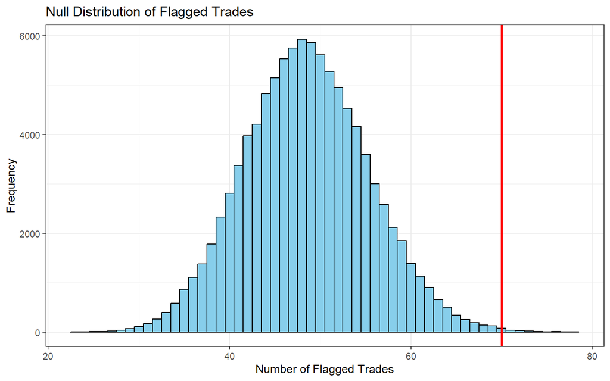

## Results

- **P-value**: 0.00204
- **Conclusion**: The null hypothesis appears implausible (p = 0.00204), suggesting the observed flag rate is significantly higher than the baseline rate.
- **One-Sentence Conclusion:** With a p-value of 0.002 (well below the significance threshold of 0.05), we reject the null hypothesis and conclude that Iron Bank’s flagged trades are occurring at a significantly higher rate than expected under random chance.

# Problem 2: Health Inspections

## Null Hypothesis:

Gourmet Bites’ true health code violation rate equals the citywide baseline rate of 3%.

## Test Statistic:

Number of health code violations (observed = 8 out of 50 inspections).

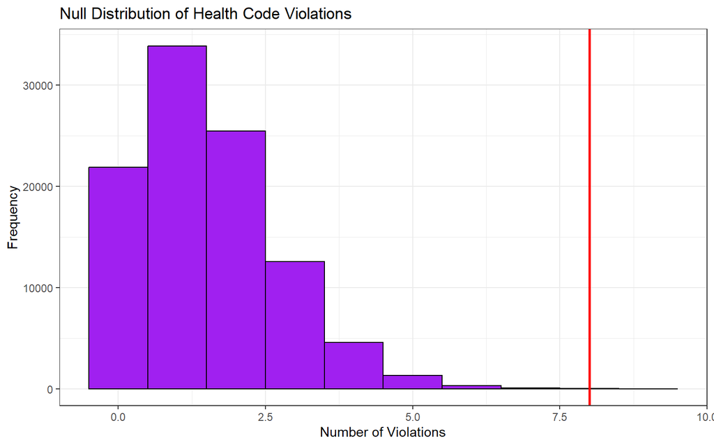

```
## Observed violations: 8
##  Expected under null: 1.5
##  P-value: 0.00013
##  Conclusion: With a p-value of 1e-04 (well below the 0.05 threshold), we reject the null hypothesis and conclude that Gourmet Bites' violation rate is significantly higher than the citywide baseline.
```

## Results

# Problem 3: Evaluating Jury Selection for Bias

### Null Hypothesis

The null hypothesis ($H_0$) is that the racial/ethnic distribution of jurors selected by this judge matches the county’s population proportions.

### Test Statistic

The test statistic is the chi-squared statistic ($\chi^2$), which measures how much the observed counts deviate from the expected counts under the null hypothesis.

### Probability Distribution Plot

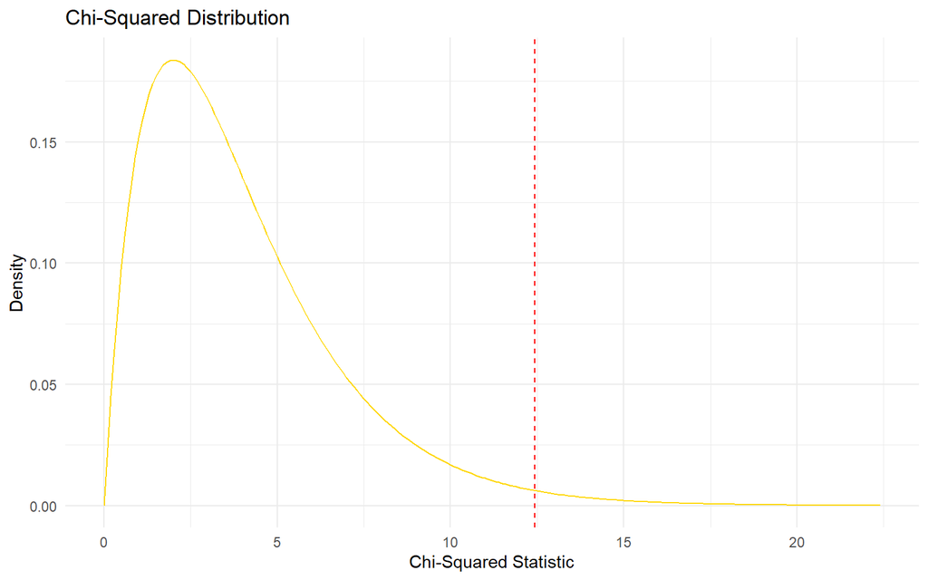

### Results

- **Chi-squared statistic**: 12.43
- **Degrees of freedom**: 4
- **P-value**: 0.0144

### Conclusion

With a p-value of 0.0144, we determine that: - If $p < 0.05$: The null hypothesis is rejected. This suggests that the observed jury composition is significantly different from the county’s population proportions and may indicate bias in jury selection. - If $p \geq 0.05$: We fail to reject the null hypothesis. This suggests no significant evidence of bias in jury selection.

**One-Sentence Conclusion:** Based on the p-value (0.0144), we conclude that there is evidence to suggest systematic bias in jury selection by this judge.

## Problem 4: LLM Watermarking

## Part A: Building the Null Distribution of the Chi-Squared Statistic

Below we load the sentences from *brown_sentences.txt* and the predefined letter frequency distribution from *letter_frequencies.csv*, then, we preprocess each sentence—removing non-letter characters, converting to uppercase, and counting letter occurrences—to compute the observed letter counts. Using the total letters in each sentence and the expected probabilities, we compute the expected counts and calculate the chi-squared statistic for each sentence, and finally, we compile these chi-squared values into our null distribution and display summary statistics and a histogram.

#### Null Hypothesis

The null hypothesis ($H_0$) is that the letter frequencies in normal English sentences follow the predefined letter frequency distribution for English (from `letter_frequencies.csv`).

```
## [1] "The Fulton County Grand Jury said Friday an investigation of Atlantas recent primary election produced  no evidence  that any irregularities took place ."
## [2] "The jury further said in termend presentments that the City Executive Committee , which had overall charge of the election ,  deserves the praise and thanks of the City of Atlanta  for the manner in which the election was conducted ."
## [3] "The SeptemberOctober term jury had been charged by Fulton Superior Court Judge Durwood Pye to investigate reports of possible  irregularities  in the hardfought primary which was won by Mayornominate Ivan Allen Jr. ."
## [4] " Only a relative handful of such reports was received  , the jury said ,  considering the widespread interest in the election , the number of voters and the size of this city  ."
## [5] "The jury said it did find that many of Georgias registration and election laws  are outmoded or inadequate and often ambiguous  ."
```

Predefined Letter Frequency Distribution

| Letter | Probability |
| --- | --- |
| A | 0.0786880 |
| B | 0.0162105 |
| C | 0.0235825 |
| D | 0.0417918 |
| E | 0.1219047 |
| F | 0.0215698 |
| G | 0.0197635 |
| H | 0.0629361 |
| I | 0.0680478 |
| J | 0.0015036 |
| K | 0.0086301 |
| L | 0.0434645 |
| M | 0.0274075 |
| N | 0.0666944 |
| O | 0.0786336 |
| P | 0.0160368 |
| Q | 0.0010457 |
| R | 0.0599032 |
| S | 0.0643802 |
| T | 0.0882601 |
| U | 0.0312808 |
| V | 0.0098249 |
| W | 0.0236999 |
| X | 0.0013949 |
| Y | 0.0228429 |
| Z | 0.0005021 |

```
##    Min. 1st Qu.  Median    Mean 3rd Qu.    Max.
##   4.689  17.643  23.255  26.950  31.381 199.242
```

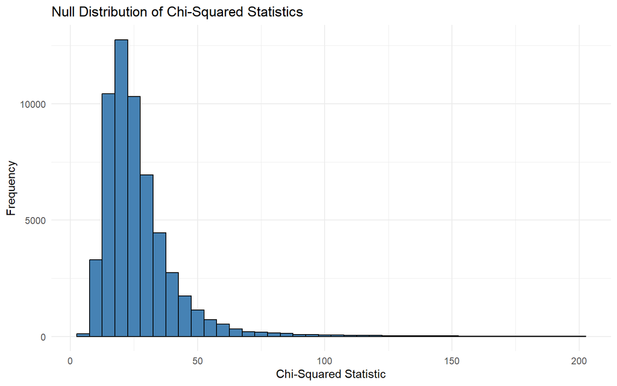

## Part B: Checking for a Watermark

Chi-Squared Statistics and P-Values for Test Sentences

|  | Sentence | Chi_Squared_Statistic | P_Value |
| --- | --- | --- | --- |
| She opened the book and started to read the first chapter, eagerly anticipating what might come next. | 1 | 22.93 | 0.513 |
| Despite the heavy rain, they decided to go for a long walk in the park, crossing the main avenue by the fountain in the center. | 2 | 13.05 | 0.926 |
| The museum’s new exhibit features ancient artifacts from various civilizations around the world. | 3 | 46.29 | 0.076 |
| He carefully examined the document, looking for any clues that might help solve the mystery. | 4 | 23.55 | 0.489 |
| The students gathered in the auditorium to listen to the guest speaker’s inspiring lecture. | 5 | 23.68 | 0.484 |
| Feeling vexed after an arduous and zany day at work, she hoped for a peaceful and quiet evening at home, cozying up after a quick dinner with some TV, or maybe a book on her upcoming visit to Auckland… | 6 | 96.45 | 0.009 |
| The chef demonstrated how to prepare a delicious meal using only locally sourced ingredients, focusing mainly on some excellent dinner recipes from Spain. | 7 | 28.27 | 0.328 |
| They watched the sunset from the hilltop, marveling at the beautiful array of colors in the sky. | 8 | 9.64 | 0.988 |
| The committee reviewed the proposal and provided many points of useful feedback to improve the project’s effectiveness. | 9 | 44.93 | 0.084 |
| Despite the challenges faced during the project, the team worked tirelessly to ensure its successful completion, resulting in a product that exceeded everyone’s expectations. | 10 | 49.96 | 0.059 |

### Results

- **Table of p-values**: The table above shows p-values for each sentence under $H_0$. Sentences with unusually low p-values may indicate deviations from typical English letter distributions.
- **Conclusion**: Based on these p-values:
  - The sentence with an unusually low p-value is likely watermarked by an LLM.
  - This suggests that its letter frequency distribution deviates significantly from normal English text.

### One-Sentence Conclusion

The sentence with the lowest p-value (6) is most likely watermarked by an LLM because its letter frequency distribution deviates significantly from typical English text as measured by a chi-squared test.